# Lecture #8: Trigonometric Identities & Trigonometric Integrals

MATH 146 – Calculus II

Torin Quinlivan

tquinlivan@knox.edu

Knox College

January 14, 2026

## Right Triangle Trigonometry

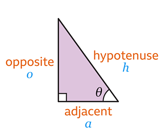

For this definition, we assume $0 \le \theta \le \frac{\pi}{2}$ or $0^\circ \le \theta \le 90^\circ$.

## Right Triangle Trigonometry

$$\begin{aligned}
\sin(\theta) &= \frac{\textrm{opposite}}{\textrm{hypotenuse}} \\[0.5em]
\cos(\theta) &= \frac{\textrm{adjacent}}{\textrm{hypotenuse}} \\[0.5em]
\tan(\theta) &= \frac{\textrm{opposite}}{\textrm{adjacent}}
\end{aligned}$$

## Right Triangle Trigonometry

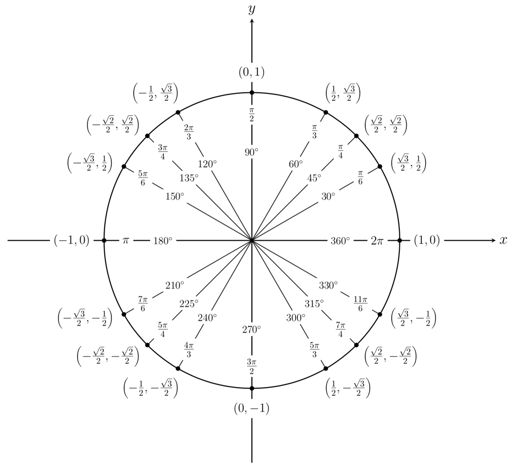

For this definition, $\theta$ can take any value.

## Right Triangle Trigonometry

$$\begin{aligned}
\sin(\theta) &= y \\[0.5em]
\cos(\theta) &= x \\[0.5em]
\tan(\theta) &= \frac{y}{x}
\end{aligned}$$

$$\begin{aligned}
\sec(\theta) &= \frac{1}{x} \\[0.5em]
\csc(\theta) &= \frac{1}{y} \\[0.5em]
\cot(\theta) &= \frac{x}{y}
\end{aligned}$$

## Trigonometric Identities

**Tangent and Cotangent Identities**

$$\begin{aligned}
\tan(\theta) &= \frac{\sin(\theta)}{\cos(\theta)} & \cot(\theta) &= \frac{\cos(\theta)}{\sin(\theta)}
\end{aligned}$$

**Reciprocal Identities**

$$\begin{aligned}
\sin(\theta) &= \frac{1}{\csc(\theta)} & \csc(\theta) &= \frac{1}{\sin(\theta)} \\
\cos(\theta) &= \frac{1}{\sec(\theta)} & \sec(\theta) &= \frac{1}{\cos(\theta)} \\
\tan(\theta) &= \frac{1}{\cot(\theta)} & \cot(\theta) &= \frac{1}{\tan(\theta)}
\end{aligned}$$

## Trigonometric Identities

**Pythagorean Identities**

$$\begin{aligned}
\sin^2(\theta) + \cos^2(\theta) = 1 \\
\tan^2(\theta) + 1 = \sec^2(\theta) \\
1 + \cot^2(\theta) = \csc^2(\theta)
\end{aligned}$$

**Even/Odd Formulas**

$$\begin{aligned}
\sin(-\theta) &= -\sin(\theta) & \csc(-\theta) &= -\csc(\theta) \\
\cos(-\theta) &= \cos(\theta) & \sec(-\theta) &= \sec(\theta) \\
\tan(-\theta) &= -\tan(\theta) & \cot(-\theta) &= -\cot(\theta)
\end{aligned}$$

## Trigonometric Identities

**Periodic Formulas**} If $n$ is an integer then:

$$\begin{aligned}
\sin(\theta + 2 \pi n) &= \sin(\theta) & \csc(\theta + 2 \pi n) = \csc(\theta) \\
\cos(\theta + 2 \pi n) &= \cos(\theta) & \sec(\theta + 2 \pi n) = \sec(\theta) \\
\tan(\theta + \pi n) &= \tan(\theta) & \cot(\theta + \pi n) = \cot(\theta)
\end{aligned}$$

**Sum and Difference Formulas**

$$\begin{aligned}
\sin(\alpha \pm \beta) &= \sin(\alpha)\cos(\beta) \pm \cos(\alpha)\sin(\beta) \\
\cos(\alpha \pm \beta) &= \cos(\alpha)\cos(\beta) \mp \sin(\alpha)\sin(\beta) \\
\tan(\alpha \pm \beta) &= \frac{\tan(\alpha) \pm \tan(\beta)}{1 \mp \tan(\alpha)\tan(\beta)}
\end{aligned}$$

## Trigonometric Identities

**Half Angle Formulas**

$$\begin{aligned}
\begin{array}{r}
\sin\left( \dfrac{\theta}{2} \right) = \pm \sqrt{\dfrac{1 - \cos(\theta)}{2}} \\[1em]
\cos\left( \dfrac{\theta}{2} \right) = \pm \sqrt{\dfrac{1 + \cos(\theta)}{2}}
\end{array} \quad \Longrightarrow \quad
\tan\left( \frac{\theta}{2} \right) &= \pm \sqrt{\frac{1 - \cos(\theta)}{1 + \cos(\theta)}}
\end{aligned}$$

## Trigonometric Identities

**Half Angle Formulas (alternate form)**

$$\begin{aligned}
\begin{array}{r}
\sin^2(\theta) = \dfrac{1 - cos(2 \theta)}{2} \\[1em]
\cos^2(\theta) = \dfrac{1 + cos(2 \theta)}{2}
\end{array} \quad \Longrightarrow \quad
\tan^2(\theta) = \dfrac{1 - cos(2\theta)}{1 + \cos(2 \theta)}
\end{aligned}$$

## Calculus on Trigonometric Functions

We know some basic formulas for trigonometric derivatives and antiderivatives:

$$\begin{aligned}
&\frac{d}{dx} \, \sin(x) = \cos(x) & &\int \cos(x) \, dx = \sin(x) + C \\
&\frac{d}{dx} \, \cos(x) = -\sin(x) & &\int \sin(x) \, dx = -\cos(x) + C \\
&\frac{d}{dx} \, \tan(x) = \sec^2(x) & &\int \sec^2(x) \, dx = \tan(x) + C \\
\end{aligned}$$

## Calculus on Trigonometric Functions

We know some basic formulas for trigonometric derivatives and antiderivatives:

$$\begin{aligned}
&\frac{d}{dx} \, \sec(x) = \sec(x) \tan(x) & &\int \sec(x) \tan(x) \, dx = \sec(x) + C \\
&\frac{d}{dx} \, \csc(x) = -\csc(x)\cot(x) & &\int \csc(x)\cot(x) \, dx = -\csc(x) + C \\
&\frac{d}{dx} \, \cot(x) = -\csc^2(x) & &\int \csc^2(x) \, dx = -\cot(x) + C \\
\end{aligned}$$

## Powers of Sines and Cosines

To integrate $\displaystyle\int \cos^j(x) \sin^k(x) \, dx$, use the following strategies:

1. If $k$ is odd, rewrite $\sin^k(x)$ as $\sin^{k-1}(x) \sin(x)$ and use the identity $\sin^2(x) = 1 - \cos^2(x)$ to rewrite $\sin^{k-1}(x)$ in terms of $\cos(x)$. Integrate using the substitution $u = \cos(x)$. This substitution makes $du = -\sin(x) \, dx$.

## Powers of Sines and Cosines

To integrate $\displaystyle\int \cos^j(x) \sin^k(x) \, dx$, use the following strategies:

2. If $j$ is odd, rewrite $\cos^j(x)$ as $\cos^{j-1}(x) \cos(x)$ and use the identity $\cos^2(x) = 1 - \sin^2(x)$ to rewrite $\cos^{j-1}(x)$ in terms of $\sin(x)$. Integrate using the substitution $u = \sin(x)$. This substitution makes $du = \cos(x) \, dx$. (*Note:* If both $j$ and $k$ are odd, either strategy 1 or strategy 2 may be used.)

## Powers of Sines and Cosines

To integrate $\displaystyle\int \cos^j(x) \sin^k(x) \, dx$, use the following strategies:

3. If both $j$ and $k$ are even, use $\sin^2(x) = \dfrac{1}{2} - \dfrac{1}{2}\cos(2x)$ and $\cos^2(x) = \dfrac{1}{2} + \dfrac{1}{2} \cos(2x)$. After applying these formulas, simplify and reapply strategies 1 through 3 as appropriate.

## Powers of Sines and Cosines

**Example:** Evaluate $\displaystyle\int \cos^3(x)\sin^2(x) \, dx$.

**Example:** Evaluate $\displaystyle\int \sin^2(x) \, dx$.

## Products of $\sin(ax)$ and $\cos(bx)$

$$\begin{aligned}
\sin(ax) \sin(bx) &= \frac{1}{2} \, \cos\big((a - b) \, x \big) - \frac{1}{2} \,\cos\big( (a + b) \, x \big) \\[2em]
\sin(ax) \cos(bx) &= \frac{1}{2} \, \sin\big((a - b) \, x \big) + \frac{1}{2} \, \sin\big( (a + b) \, x \big) \\[2em]
\cos(ax) \cos(bx) &= \frac{1}{2} \, \cos\big((a - b) \, x \big) + \frac{1}{2} \, \cos\big( (a + b) \, x \big)
\end{aligned}$$

## Powers of Sines and Cosines

**Example:** Evaluate $\displaystyle\int \sin^2(x)\cos^2(x) \, dx$.

## Powers of Tangents and Secants

$$\begin{aligned}
&\int \sec^2(x) \, dx = \tan(x) + C \\
&\int \sec(x) \tan(x) \, dx = \sec(x) + C \\
&\int \tan(x) \, dx = \ln \lvert \sec(x) \rvert + C \\
&\int \sec(x) \, dx = \ln \lvert \sec(x) + \tan(x) \rvert + C
\end{aligned}$$

Integrals involving $\displaystyle\int \tan^j(x) \sec(x)^2 \, dx$ and $\displaystyle\int \sec^j(x) \tan(x) \, dx$ can also be done by substitution.

## Powers of Tangents and Secants

To integrate $\displaystyle\int \tan^k(x) \sec^j(x) \, dx$, use the following strategies:

1. If $j$ is even and $j \ge 2$, rewrite $\sec^j(x)$ as $\sec^{j-2}(x) \sec^2(x)$ and use $\sec^2(x) = \tan^2(x) + 1$ to rewrite $\sec^{j-2}(x)$ in terms of $\tan(x)$. Let $u = \tan(x)$ and $du = \sec^2(x) \, dx$.

## Powers of Tangents and Secants

To integrate $\displaystyle\int \tan^k(x) \sec^j(x) \, dx$, use the following strategies:

2. If $k$ is odd and $j \ge 1$, rewrite $\tan^k(x) \sec^j(x)$ as $\tan^{k-1}(x) \sec^{j-1}(x) \sec(x) \tan(x)$ and use $\tan^2(x) = \sec^2(x) - 1$ to rewrite $\tan^{k-1}(x)$ in terms of $\sec(x)$. Let $u = \sec(x)$ and $du = \sec(x)\tan(x) \, dx$. (*Note:* If $j$ is even and $k$ is odd, then either strategy 1 or strategy 2 may be used.)

## Powers of Tangents and Secants

To integrate $\displaystyle\int \tan^k(x) \sec^j(x) \, dx$, use the following strategies:

3. If $k$ is odd where $k \ge 3$ and $j = 0$, rewrite $\tan^k(x)$ as $\tan^{k-2}(x)\sec^2(x) - \tan^{k-2}(x)$. It may be necessary to repeat this process on the $\tan^{k-2}(x)$ term.

$$\begin{aligned}
\tan^k(x) &= \tan^{k-2}(x) \tan^2(x) \\
&= \tan^{k-2}(x) (\sec^2(x) - 1) \\
&= \tan^{k-2}(x)\sec^2(x) - \tan^{k-2}(x)
\end{aligned}$$

## Powers of Tangents and Secants

To integrate $\displaystyle\int \tan^k(x) \sec^j(x) \, dx$, use the following strategies:

4. If $k$ is even and $j$ is odd, then use $\tan^2(x)$ as $\sec^2(x) - 1$ to express $\tan^k(x)$ in terms of $\sec(x)$. Use integration by parts to integrate odd powers of $\sec(x)$.

## Powers of Tangents and Secants

**Example:** Evaluate $\displaystyle\int \tan^4(x)\sec^4(x) \, dx$.

**Example:** Evaluate $\displaystyle\int \tan^3(x) \, dx$.

**Example:** Evaluate $\displaystyle\int \sec^3(x) \, dx$.

## Powers of Tangents and Secants

Using integration by parts (as before), we can derive the following for powers of secants or tangents.

$$\begin{aligned}
\int \sec^n(x) \, dx &= \frac{1}{n-1} \, \sec^{n-2}(x) \tan(x) + \frac{n-2}{n-1} \int \sec^{n-2}(x) \, dx \\[1em]
\int \tan^n(x) \, dx &= \frac{1}{n-1} \tan^{n-1}(x) - \int \tan^{n-2}(x) \, dx
\end{aligned}$$